# Diversity project actual analyses I swear

```r
ggsave("fig3_organ_by_descriptor_slim.pdf", width = 7, height = 4.5)
ggsave("fig3_organ_by_descriptor_slim.png", width = 7, height = 4.5)

# Some statistics: The percentage of samples that each tissue accounts for, and how many descriptors are associated:
allSRAFinal %>% count(hasDescriptor, finalOrgan) %>% group_by(hasDescriptor) %>% summarise(finalOrgan = finalOrgan, n = n, proportion = n/sum(n)) %>% as.data.frame
```

```
##    hasDescriptor           finalOrgan    n   proportion
## 1     Geographic              Adipose   54 5.508518e-03
## 2     Geographic              Bladder   10 1.020096e-03
## 3     Geographic           Blastoderm   22 2.244211e-03
## 4     Geographic                Blood 5087 5.189228e-01
## 5     Geographic         Blood vessel  131 1.336326e-02
## 6     Geographic          Bone marrow  102 1.040498e-02
## 7     Geographic                Brain  612 6.242987e-02
## 8     Geographic               Breast   35 3.570336e-03
## 9     Geographic                  CNS   15 1.530144e-03
## 10    Geographic Cancer sample\n(NOS)   17 1.734163e-03
## 11    Geographic                Heart  195 1.989187e-02
## 12    Geographic                 IPSC  901 9.191064e-02
## 13    Geographic            Intestine  866 8.834030e-02
## 14    Geographic                Joint   92 9.384882e-03
```

[output cut: 51 more lines]

```r
allSRAFinal %>% drop_na(strictestGeography, finalOrgan) %>% count(finalOrgan, strictestGeography) %>% group_by(finalOrgan) %>% summarise(geoGroups = length(finalOrgan)) %>% arrange(desc(geoGroups)) %>% as.data.frame
```

```
##              finalOrgan geoGroups
## 1                 Blood        10
## 2                 Brain         7
## 3             Intestine         6
## 4                 Joint         6
## 5                 Heart         5
## 6                  IPSC         5
## 7          Blood vessel         4
## 8                  Lung         4
## 9                  Skin         4
## 10          Bone marrow         3
## 11 Cancer sample\n(NOS)         3
## 12               Kidney         3
## 13                Liver         3
## 14               Muscle         3
## 15               Testis         3
## 16                  CNS         2
## 17             Prostate         2
## 18              Thyroid         2
## 19              Adipose         1
## 20              Bladder         1
## 21           Blastoderm         1
## 22               Breast         1
## 23               Morula         1
## 24                 Nose         1
## 25             Placenta         1
## 26              Trachea         1
```

```r
allSRAFinal %>% drop_na(strictestRace, finalOrgan) %>% count(finalOrgan, strictestRace) %>% group_by(finalOrgan) %>% summarise(raceGroups = length(finalOrgan)) %>% arrange(desc(raceGroups)) %>% as.data.frame
```

```
##              finalOrgan raceGroups
## 1                 Blood          8
## 2  Cancer sample\n(NOS)          7
## 3                  Nose          6
## 4          Blood vessel          5
## 5                Breast          5
## 6                 Heart          5
## 7             Intestine          5
## 8                 Ovary          5
## 9           Bone marrow          4
## 10                 IPSC          4
## 11                 Lung          4
## 12          Oral cavity          4
## 13                 Skin          4
## 14              Adipose          3
```

[output cut: 23 more lines]

```r
# And how many tissues is each descriptor associated with?
allSRAFinal %>% drop_na(strictestGeography, finalOrgan) %>% count(finalOrgan)
```

```
##              finalOrgan    n
## 1               Adipose   54
## 2               Bladder   10
## 3            Blastoderm   22
## 4                 Blood 5087
## 5          Blood vessel  131
## 6           Bone marrow  102
## 7                 Brain  612
## 8                Breast   35
## 9                   CNS   15
## 10 Cancer sample\n(NOS)   17
## 11                Heart  195
## 12                 IPSC  901
## 13            Intestine  866
## 14                Joint   92
## 15               Kidney   24
## 16                Liver   99
## 17                 Lung  213
## 18               Morula   41
## 19               Muscle  806
## 20                 Nose   35
## 21             Placenta   32
## 22             Prostate  126
## 23                 Skin  174
## 24               Testis   14
## 25              Thyroid   34
## 26              Trachea   12
```

```r
allSRAFinal %>% drop_na(strictestRace, finalOrgan) %>% count(finalOrgan)
```

```
##              finalOrgan    n
## 1               Adipose   53
## 2         Adrenal gland    3
## 3               Bladder    2
## 4                 Blood 8929
## 5          Blood vessel   50
## 6           Bone marrow   52
## 7                 Brain 1084
## 8                Breast  466
## 9  Cancer sample\n(NOS)  721
## 10            Cartilage    3
## 11      Digestive tract    2
## 12                  Eye   47
## 13                Heart  579
## 14                 IPSC  716
```

[output cut: 23 more lines]

```r
allSRAFinal %>% drop_na(strictestGeography, finalOrgan) %>% count(finalOrgan, strictestGeography) %>% group_by(strictestGeography) %>% summarise(geoGroups = length(strictestGeography)) %>% arrange(desc(geoGroups)) %>% as.data.frame
```

```
##                strictestGeography geoGroups
## 1                          Europe        21
## 2              Sub-Saharan Africa        15
## 3                       East Asia        12
## 4                      Asia (NOS)        12
## 5                      South Asia         6
## 6                        Americas         6
## 7  North Africa and\nWestern Asia         4
## 8                           Other         3
## 9                        Multiple         2
## 10                 Southeast Asia         1
## 11                        Oceania         1
```

```r
allSRAFinal %>% drop_na(strictestRace, finalOrgan) %>% count(finalOrgan, strictestRace) %>% group_by(strictestRace) %>% summarise(raceGroups = length(strictestRace)) %>% arrange(desc(raceGroups)) %>% as.data.frame
```

```
##                                 strictestRace raceGroups
## 1                                       White         35
## 2                  Black or\nAfrican American         24
## 3                                    Hispanic         15
## 4                                       Asian         14
## 5                                    Multiple         12
## 6          American Indian and\nAlaska Native          6
## 7                                       Other          4
## 8 Native Hawaiian and\nother Pacific Islander          1
```

```r
allSRAFinal %>% drop_na(strictestRace, finalOrgan) %>% count(finalOrgan, strictestRace) %>% group_by(strictestRace) %>% as.data.frame
```

```
##               finalOrgan                               strictestRace    n
## 1                Adipose                  Black or\nAfrican American   22
## 2                Adipose                                    Multiple    1
## 3                Adipose                                       White   30
## 4          Adrenal gland                                       White    3
## 5                Bladder                                    Multiple    1
## 6                Bladder                                       White    1
## 7                  Blood          American Indian and\nAlaska Native   32
## 8                  Blood                                       Asian  513
## 9                  Blood                  Black or\nAfrican American  839
## 10                 Blood                                    Hispanic 1036
## 11                 Blood                                    Multiple  178
## 12                 Blood Native Hawaiian and\nother Pacific Islander    6
## 13                 Blood                                       Other  155
## 14                 Blood                                       White 6170
```

[output cut: 97 more lines]

```r
allSRAFinal %>% drop_na(strictestRace) %>% filter(!grepl("White", finalRace)) %>% filter(is.na(finalOrgan))
```

```
##   SRA.Study                            Center.Name    BioSample     Organism  LibrarySource Cell_type     Tissue Cell_line
## 1 SRP068304 LIEBER INSTITUTE FOR BRAIN DEVELOPMENT SAMN03463726 Homo sapiens TRANSCRIPTOMIC Firoblast Connective      <NA>
## 2 SRP068304 LIEBER INSTITUTE FOR BRAIN DEVELOPMENT SAMN03463725 Homo sapiens TRANSCRIPTOMIC Firoblast Connective      <NA>
## 3 SRP068304 LIEBER INSTITUTE FOR BRAIN DEVELOPMENT SAMN03463730 Homo sapiens TRANSCRIPTOMIC Firoblast Connective      <NA>
## 4 SRP068304 LIEBER INSTITUTE FOR BRAIN DEVELOPMENT SAMN03463729 Homo sapiens TRANSCRIPTOMIC Firoblast Connective      <NA>
##                                                                     disease ETHNICITY disease_state Diagnosis tissue_type clinical_information RACE health_state Population
## 1                 No Dx on Axis I (Develop&lt;18);Deferred;Other (Specify);      <NA>          <NA>      <NA>        <NA>                 <NA>   AA         <NA>       <NA>
## 2                 No Dx on Axis I (Develop&lt;18);Deferred;Other (Specify);      <NA>          <NA>      <NA>        <NA>                 <NA>   AA         <NA>       <NA>
## 3 No Diagnosis on Axis 1;Deferred;Fatty liver;Atherosclerotic CVD (ASHCVD);      <NA>          <NA>      <NA>        <NA>                 <NA> HISP         <NA>       <NA>
## 4 No Diagnosis on Axis 1;Deferred;Fatty liver;Atherosclerotic CVD (ASHCVD);      <NA>          <NA>      <NA>        <NA>                 <NA> HISP         <NA>       <NA>
##   DONOR_HEALTH_STATUS DONOR_ETHNICITY reported_race ReleaseDate         create_date ancestry donor_id Sample_type source_name source_material_cell_type source_material
## 1                <NA>            <NA>          <NA>  2016-04-06 2016-01-15 13:40:00     <NA>     <NA>        <NA>        <NA>                      <NA>            <NA>
## 2                <NA>            <NA>          <NA>  2016-04-06 2016-01-16 11:04:00     <NA>     <NA>        <NA>        <NA>                      <NA>            <NA>
## 3                <NA>            <NA>          <NA>  2016-04-06 2016-01-15 13:46:00     <NA>     <NA>        <NA>        <NA>                      <NA>            <NA>
## 4                <NA>            <NA>          <NA>  2016-04-06                <NA>     <NA>     <NA>        <NA>        <NA>                      <NA>            <NA>
##   Organism_part race.ethnicity primary_race SAMPLE_TYPE Sampling_site                  finalRace finalGeography hispanic       finalSystem finalOrgan    finalDisease
## 1          <NA>           <NA>         <NA>        <NA>          <NA> Black or\nAfrican American           <NA>     <NA> Connective tissue       <NA> Healthy control
## 2          <NA>           <NA>         <NA>        <NA>          <NA> Black or\nAfrican American           <NA>     <NA> Connective tissue       <NA> Healthy control
## 3          <NA>           <NA>         <NA>        <NA>          <NA>                       <NA>           <NA> Hispanic Connective tissue       <NA> Healthy control
## 4          <NA>           <NA>         <NA>        <NA>          <NA>                       <NA>           <NA> Hispanic Connective tissue       <NA> Healthy control
##                                finalSite finalCountry strictestGeography              strictestRace strictGeography                 strictRace       pc1        pc2   assay
## 1 LIEBER INSTITUTE FOR BRAIN DEVELOPMENT          USA               <NA> Black or\nAfrican American            <NA> Black or\nAfrican American 18.915913  0.8413359 rna-seq
## 2 LIEBER INSTITUTE FOR BRAIN DEVELOPMENT          USA               <NA> Black or\nAfrican American            <NA> Black or\nAfrican American 19.427752  0.5760796 rna-seq
## 3 LIEBER INSTITUTE FOR BRAIN DEVELOPMENT          USA               <NA>                   Hispanic            <NA>                       <NA> -7.020898 -2.0092828 rna-seq
## 4 LIEBER INSTITUTE FOR BRAIN DEVELOPMENT          USA               <NA>                   Hispanic            <NA>                       <NA> -7.261644 -2.2739752 rna-seq
##   percent_zero pred_pop missingness                 backupRace backupHispanic   worldBank   worldRegion hasDescriptor
## 1     7.727935      AFR      (0,10] Black or\nAfrican American           <NA> High income North America        Racial
## 2     7.096356      AFR      (0,10] Black or\nAfrican American           <NA> High income North America        Racial
## 3     7.446154      SAS      (0,10]                       <NA>       Hispanic High income North America        Racial
## 4     7.750607      SAS      (0,10]                       <NA>       Hispanic High income North America        Racial
```

```r
allSRAFinal %>% drop_na(strictestRace) %>% filter(grepl("White", finalRace)) %>% filter(is.na(finalOrgan))
```

```
##    SRA.Study                            Center.Name    BioSample     Organism  LibrarySource Cell_type     Tissue Cell_line
## 1  SRP043166                                    GEO SAMN02852956 Homo sapiens TRANSCRIPTOMIC      <NA>   Pterygia      <NA>
## 2  SRP043166                                    GEO SAMN02852957 Homo sapiens TRANSCRIPTOMIC      <NA>   Pterygia      <NA>
## 3  SRP043166                                    GEO SAMN02852961 Homo sapiens TRANSCRIPTOMIC      <NA>   Pterygia      <NA>
## 4  SRP043166                                    GEO SAMN02852955 Homo sapiens TRANSCRIPTOMIC      <NA>   Pterygia      <NA>
## 5  SRP043166                                    GEO SAMN02852959 Homo sapiens TRANSCRIPTOMIC      <NA>   Pterygia      <NA>
## 6  SRP043166                                    GEO SAMN02852964 Homo sapiens TRANSCRIPTOMIC      <NA>   Pterygia      <NA>
## 7  SRP043166                                    GEO SAMN02852954 Homo sapiens TRANSCRIPTOMIC      <NA>   Pterygia      <NA>
## 8  SRP043166                                    GEO SAMN02852958 Homo sapiens TRANSCRIPTOMIC      <NA>   Pterygia      <NA>
## 9  SRP043166                                    GEO SAMN02852963 Homo sapiens TRANSCRIPTOMIC      <NA>   Pterygia      <NA>
## 10 SRP043166                                    GEO SAMN02852965 Homo sapiens TRANSCRIPTOMIC      <NA>   Pterygia      <NA>
## 11 SRP043166                                    GEO SAMN02852960 Homo sapiens TRANSCRIPTOMIC      <NA>   Pterygia      <NA>
## 12 SRP043166                                    GEO SAMN02852962 Homo sapiens TRANSCRIPTOMIC      <NA>   Pterygia      <NA>
## 13 SRP068304 LIEBER INSTITUTE FOR BRAIN DEVELOPMENT SAMN03463731 Homo sapiens TRANSCRIPTOMIC Firoblast Connective      <NA>
## 14 SRP068304 LIEBER INSTITUTE FOR BRAIN DEVELOPMENT SAMN03463728 Homo sapiens TRANSCRIPTOMIC Firoblast Connective      <NA>
```

[output cut: 171 more lines]

```r
# And now some alluvial plots, for funsies and supplementary data:
allSRAFinal %>% drop_na(strictestGeography) %>% count(worldRegion)
```

```
##                  worldRegion    n
## 1       East Asia &\nPacific 1420
## 2     Europe &\nCentral Asia 3434
## 3 Latin America &\nCaribbean   84
## 4              North America 4807
## 5                 South Asia   26
## 6                       <NA>   32
```

```r
allSRAFinal %>% drop_na(strictestRace) %>% count(worldRegion)
```

```
##                   worldRegion     n
## 1        East Asia &\nPacific   378
## 2      Europe &\nCentral Asia  2512
## 3 Middle East &\nNorth Africa    11
## 4               North America 11099
```

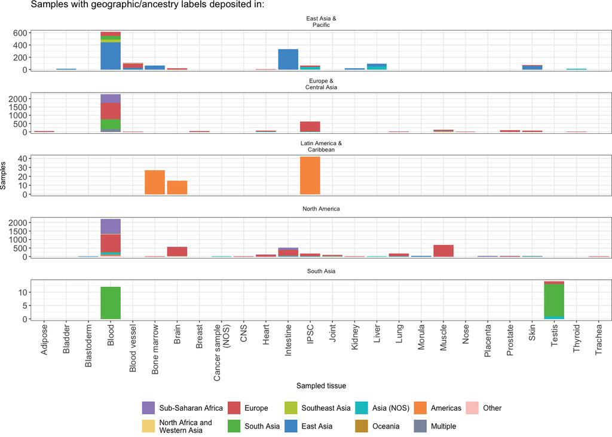

```r
geoTissueFacet <- geographySummary %>% group_by(finalOrgan, strictestGeography, worldRegion) %>% summarise(value = sum(n)) %>% distinct() %>% drop_na(c(finalOrgan, strictestGeography, worldRegion)) %>% as.data.frame %>%
  ggplot(., aes(x = finalOrgan, y = value, fill = strictestGeography)) +
  geom_bar(stat="identity") +
  ggtitle("Samples with geographic/ancestry labels deposited in:") +
  xlab("Sampled tissue") +
  ylab("Samples") +
  scale_fill_geography(name="Population\nDescriptor") +
  guides(fill=guide_legend(title="", nrow=2)) +
  theme(axis.text.x = element_text(angle = 90, hjust=1, vjust=0.5)) +
  theme(legend.title = element_blank(), legend.position="bottom", legend.direction="horizontal") +
  theme(strip.background = element_blank()) +
  facet_wrap(~worldRegion, ncol=1, scales="free_y")
geoTissueFacet
```

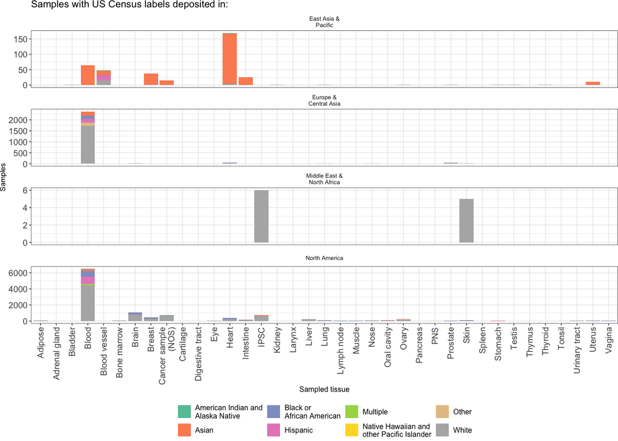

```r
ggsave("fig3_organ_by_geography_faceted.pdf", width=6, height=9)
ggsave("fig3_organ_by_geography_faceted.png", width=6, height=9)

raceTissueFacet <- raceSummary %>% group_by(finalOrgan, strictestRace, worldRegion) %>% summarise(value = sum(n)) %>% distinct() %>% drop_na(c(finalOrgan, strictestRace, worldRegion)) %>% as.data.frame %>%
  ggplot(., aes(x = finalOrgan, y = value, fill = strictestRace)) +
  geom_bar(stat="identity") +
  ggtitle("Samples with US Census labels deposited in:") +
  xlab("Sampled tissue") +
  ylab("Samples") +
  scale_fill_race(name="US Census\nTerm)") +
  guides(fill=guide_legend(title="")) +
  theme(axis.text.x = element_text(angle = 90, hjust=1, vjust=0.5)) +
  theme(legend.title = element_blank(), legend.position="bottom", legend.direction="horizontal") +
  theme(strip.background = element_blank()) +
  facet_wrap(~worldRegion, ncol=1, scales="free_y")
raceTissueFacet
```

```r
ggsave("fig3_organ_by_race_faceted.pdf", width=6, height=9)
ggsave("fig3_organ_by_race_faceted.png", width=6, height=9)
```

And now we should ask, since these proportions look different, are there differences? Is having a given descriptor associated with higher likelihood or something or something else being sequenced?

We can do this at the `hasDescriptor` level (racial vs geographic), at the `finalCountry` level and at the `worldRegion` level, although we also might want to consider the actual descriptors

But first, an easier question: Is blood really more diverse than anything else?

```r
bloodPropGeo <- allSRAFinal %>% filter(grepl("Blood", finalOrgan) & !is.na(strictestGeography)) %>%
  count(strictestGeography) %>%
  mutate(freq = n/sum(n))

nobloodPropGeo <- allSRAFinal %>% filter(!grepl("Blood", finalOrgan) & !is.na(strictestGeography)) %>%
  count(strictestGeography) %>%
  mutate(freq = n/sum(n))

bloodPropRace <- allSRAFinal %>% filter(grepl("Blood", finalOrgan) & !is.na(strictestRace)) %>%
  count(strictestRace) %>%
  mutate(freq = n/sum(n))

nobloodPropRace <- allSRAFinal %>% filter(!grepl("Blood", finalOrgan) & !is.na(strictestRace)) %>%
  count(strictestRace) %>%
  mutate(freq = n/sum(n))

geoBlood <- full_join(bloodPropGeo, nobloodPropGeo, by="strictestGeography", suffix=c("Blood", "NoBlood")) %>%
  full_join(., geographyProp, by="strictestGeography") %>%
  mutate(across(where(is.numeric), ~replace(., is.na(.), 0)))

raceBlood <- full_join(bloodPropRace, nobloodPropRace, by="strictestRace", suffix=c("Blood", "NoBlood")) %>%
  full_join(., raceProp, by="strictestRace") %>%
  mutate(across(where(is.numeric), ~replace(., is.na(.), 0)))

chisq.test(geoBlood[,c(2,6)])
```

```
##
##  Pearson's Chi-squared test
##
## data:  geoBlood[, c(2, 6)]
## X-squared = 499.42, df = 10, p-value < 2.2e-16
```

```r
chisq.test(raceBlood[,c(2,6)])
```

```
##
##  Pearson's Chi-squared test
##
## data:  raceBlood[, c(2, 6)]
## X-squared = 115.87, df = 7, p-value < 2.2e-16
```

```r
# Both are significant but blood is clearly a lot more diverse
geoBlood
```

```
##                strictestGeography nBlood   freqBlood nNoBlood freqNoBlood    n        freq
## 1              Sub-Saharan Africa   1402 0.268685320      285 0.062159215 1687 0.172090176
## 2  North Africa and\nWestern Asia     12 0.002299732        6 0.001308615   18 0.001836173
## 3                          Europe   2194 0.420467612     3257 0.710359869 5451 0.556054269
## 4                      South Asia    693 0.132809506       25 0.005452563  718 0.073242885
## 5                  Southeast Asia     49 0.009390571        0 0.000000000   49 0.004998470
## 6                       East Asia    471 0.090264469      643 0.140239913 1114 0.113638682
## 7                      Asia (NOS)    109 0.020889230      197 0.042966194  306 0.031214934
## 8                        Americas     53 0.010157148      127 0.027699019  180 0.018361726
## 9                        Multiple    180 0.034495975       27 0.005888768  207 0.021115985
## 10                          Other     55 0.010540437        7 0.001526718   62 0.006324595
## 11                        Oceania      0 0.000000000       11 0.002399128   11 0.001122105
```

```r
raceBlood
```

```
##                                 strictestRace nBlood    freqBlood nNoBlood freqNoBlood    n         freq
## 1          American Indian and\nAlaska Native     34 0.0037866132       11 0.002190799   45 0.0032142857
## 2                                       Asian    528 0.0588038757      408 0.081258713  936 0.0668571429
## 3                  Black or\nAfrican American    840 0.0935516204      892 0.177653854 1732 0.1237142857
## 4                                    Hispanic   1050 0.1169395256      197 0.039235212 1247 0.0890714286
## 5                                    Multiple    178 0.0198240339       25 0.004979088  203 0.0145000000
## 6 Native Hawaiian and\nother Pacific Islander      6 0.0006682259        0 0.000000000    6 0.0004285714
## 7                                       Other    155 0.0172625014        7 0.001394145  162 0.0115714286
## 8                                       White   6188 0.6891636040     3481 0.693288190 9669 0.6906428571
```

```r
allPropGeo <- allSRAFinal %>% filter(!is.na(worldRegion)) %>%
  group_by(worldRegion) %>%
  count(finalOrgan) %>%
  as.data.frame()

# Not very promising...
anova(lm(n ~ finalOrgan + worldRegion, data=allPropGeo))
```

```
## Analysis of Variance Table
##
## Response: n
##             Df   Sum Sq Mean Sq F value  Pr(>F)
## finalOrgan  42 45042698 1072445  0.9769 0.53336
## worldRegion  5 15560730 3112146  2.8350 0.03086 *
## Residuals   33 36226373 1097769
## ---
## Signif. codes:  0 '***' 0.001 '**' 0.01 '*' 0.05 '.' 0.1 ' ' 1
```

```r
allPropGeo <- allPropGeo %>%
  cast(., worldRegion ~ finalOrgan) %>%
  mutate(across(where(is.numeric), ~replace(., is.na(.), 0)))
# Boring, uninterpretable, cannot be bothered to go any further. Keep it descriptive
chisq.test(allPropGeo[,2:ncol(allPropGeo)])
```

```
##
##  Pearson's Chi-squared test
##
## data:  allPropGeo[, 2:ncol(allPropGeo)]
## X-squared = 20735, df = 215, p-value < 2.2e-16
```